# Assignment #3

17 points

Author

Esteban Montenegro-Montenegro

Published

September 15, 2022

## Description

In this assignment you’ll have to answer questions based on the presentation *Introduction to Probability and Statistics* and the lecture *Probability distributions and random variables*. Also, you may need to check the examples provided by Westfall & Henning (2013) (Chapter 1).

Please submit your answers in a Word document or Libre Office document with a cover page. Copy the question and then answer the question in the following paragraph, similar to this example

*1) What is a parameter?*

*Answer: A parameter is an unknown value in a model, but it will be estimated using the data*

## Relevant questions realated to NATURE

Please answer the following questions, if you find yourself not understanding the question please send me an email or schedule an appointment. My aim is to evaluate if I did a good job communicating the main points, in addition I aim to evaluate if you understood the content.

1. Let’s imagine that you need a model relating crime rate in a “typical” city to the poverty, then you came up with the next model:

$$\begin{equation}
CrimeRate = 60+5*Poverty
\end{equation}$$

1.1) What kind of model is this? Provide the right term from the presentation or from page 8 in Westfall & Henning (2013). (3 points)

1.2) Is this model good to study crime? Answer this question based on the lecture or based on page 9 in Westfall & Henning (2013). (3 points)

2. In page 13, Westfall & Henning (2013) define a *Purely Probabilistic Statistical Model* as:

*A purely probabilistic statistical model states that a variable $Y$ is produced by a pdf having unknown parameters. In symbolic shorthand, the model is given as $Y \sim p(y|\theta)$*

Based on this definition, please write the name of three probability models we studied in class. (Hint: Check the lecture *Probability distributions and random variables*) (3 points)

3. We studied in class that models generate data, what is the distribution of the following model?, and what information is assumed in population model o data generating process? (4 points)

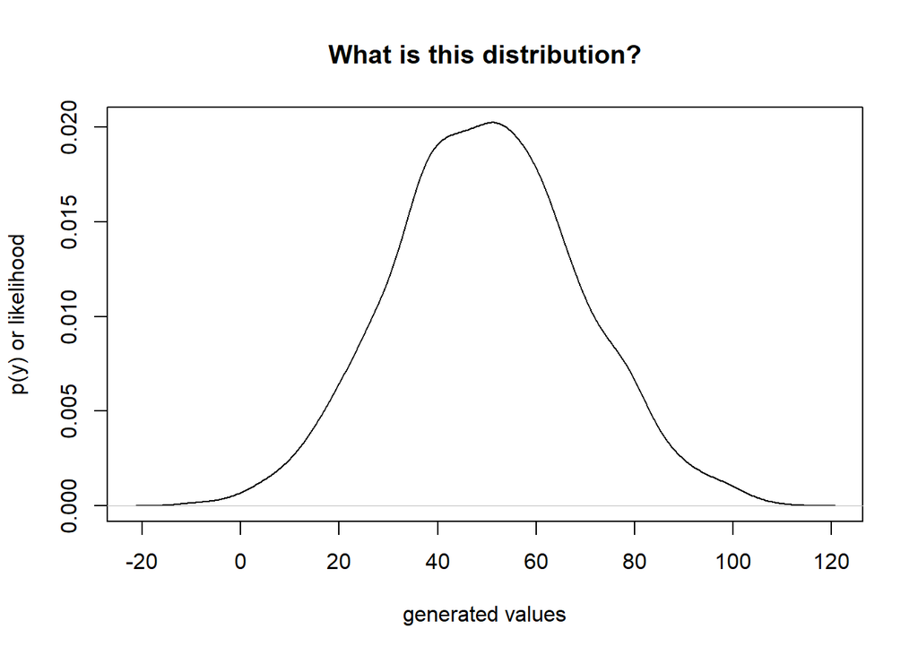

```r
## Average or mean
Mean <- 50
## Standard deviation
SD <- 20
N <- 2000

generatedValues <- rnorm(n = N, mean = Mean, sd = SD )

plot(density(generatedValues),
     xlab = "generated values",
     ylab = "p(y) or likelihood",
     main = "What is this distribution?")
```

4. I explained in class that simulations are good for learning complicated topics in statistics. I also mentioned that simulations help to explain the concept of DATA (uppercase) versus data (lowercase). Explain the concept of *DATA* and **data** using the example of tossing a coin (3 points). When we simulate one data set using the Bernoulli distribution, is this data set **DATA*** or *data*? (1 point)

## Extra points (5 points)

Create a good meme to express how you feel in this class, include your meme in your Word document.

[figure not shown]

## References

Westfall, P. H., & Henning, K. S. (2013). *Understanding advanced statistical methods*. CRC Press Boca Raton, FL, USA: